# Lab 5 – Inference for Categorical Data

## Lab Report Template

Your reproducible lab report – Before you get started, download the R Markdown template for this lab. Remember all of your code and answers go in this document:

```r
download.file("https://jacobfhsmith.github.io/STA101-Fall-2021/sta101_lab5.Rmd", destfile="sta101_lab5.Rmd")
```

In August of 2012, news outlets ranging from the [Washington Post](http://www.washingtonpost.com/national/on-faith/poll-shows-atheism-on-the-rise-in-the-us/2012/08/13/90020fd6-e57d-11e1-9739-eef99c5fb285_story.html) to the [HuffingtonPost](http://www.huffingtonpost.com/2012/08/14/atheism-rise-religiosity-decline-in-america_n_1777031.html) ran a story about the rise of atheism in America. The source for the story was a Gallup Poll that asked people, “Irrespective of whether you attend a place of worship or not, would you say you are a religious person, not a religious person or a convinced atheist?” This type of question, which asks people to classify themselves in one way or another, is common in polling and generates categorical data. In this lab we take a look at the atheism survey and explore what’s at play when making inference about population proportions using categorical data.

## Load packages

In this lab, we will explore and visualize the data using the `tidyverse` suite of packages. We’ll also use the `statsr` package for inference. Let’s load the packages. Note that if running `library(statsr)` gives you a message saying `Error in library(statsr) : there is no package called ‘statsr’`saying , then run `install.packages('statsr')` in your console. If that doesn’t work, try `install.packages("statsr", dependencies = TRUE, INSTALL_opts = '--no-lock')`

```r
library(tidyverse)
library(statsr)
```

## The survey

To access the press release for the poll, conducted by WIN-Gallup International, click [here](https://github.com/jacobfhsmith/STA101-Fall-2021/blob/main/GallupReport.pdf?raw=true) to download it.

Take a moment to review the report and its methodology before moving on.

First, please answer these questions about the report itself.

#### Exercise 1 (10 points)

*Look at Table 1 on page 10 of the report. What country has the highest rate of religiosity according to the 2012 survey? What percentage of people in this country say that they are religious? Is this value of religiosity most likely a sample statistic (derived from a data sample) or a population parameter?

Now, turn your attention to Table 6 on pages 14 and 15 of the report.

#### Exercise 2 (10 points)

How many people were sampled in Austria in 2012? How does its sample size compare to other countries in the report? Why do you think most countries have the sample sizes they do? (Note: this is a conceptual question, you don’t have to any specific calculations. Your answer here will be helpful on a future question.)

## The Data

Having now seen this summary of the data, we’ll now look at the individual responses to this survey. Load the data with this command:

```r
load(url("http://www.openintro.org/stat/data/atheism.RData"))
```

Let’s consider the data for Austria, which we’ve already looked at. Table 4 shows that Austria had an estimated 10% of individuals identifying as atheist in 2012, the same percentage as in 2005.

#### Exercise 3 (10 points)

Using `filter` and `summarize` in `dplyr, create a new dataframe called`aut12`that contains only the rows in`atheism` associated with respondents to the 2012 survey in Austria? What is the percentage here and is it the same as the percentage in the report?

## Inference on proportions

Table 6 in the report provides *statistics*, which are calculated from the sample of 51,927 people taken in 2012. Our goal in taking these samples and calculating associated statistics is to estimate population *parameters*. The inferential tools for estimating population proportion include the confidence interval and the hypothesis test.

#### Exercise 4 (10 points)

What are the conditions for inference to construct a 95% confidence interval for the proportion of atheists in Austria in 2012. Are you confident all conditions are met?

If the conditions for inference are reasonable, we can calculate the standard error and construct a confidence interval. You can do this by hand, but here in lab, we’ll allow the [`inference`](https://www.rdocumentation.org/packages/statsr/versions/0.1-0/topics/inference) function to do it for us.

Note that since the goal is to construct an interval estimate for a proportion, it’s necessary to specify what constitutes a “success”, which here is a response of `"atheist"`.

The below code allows us to find a confidence interval.

```r
aut_data <- atheism %>%
  filter(nationality == "Austria" & year == "2012")
statsr::inference(data = aut_data, y = response, success = "atheist",
                  statistic = "proportion", type = "ci", method = "theoretical")
```

```
## Single categorical variable, success: atheist
## n = 1002, p-hat = 0.0998
## 95% CI: (0.0812 , 0.1184)
```

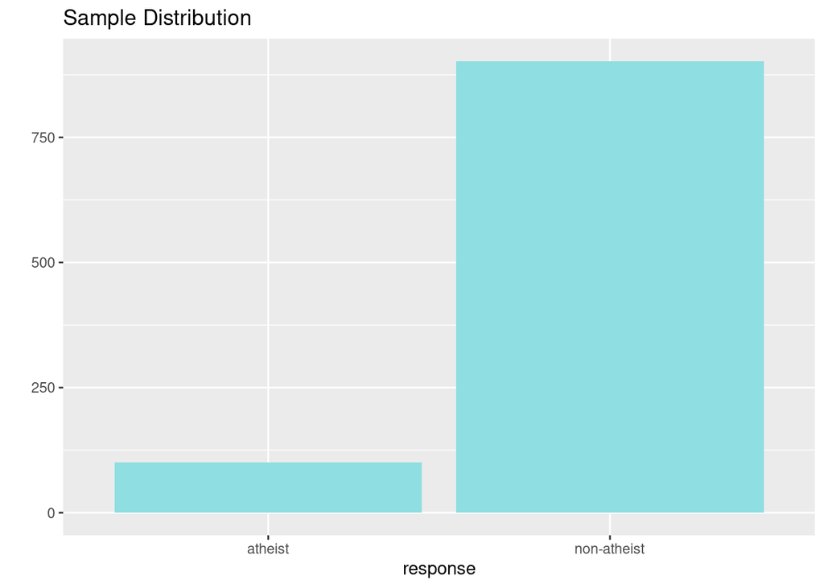

#### Exercise 5 (10 points)

Based on the R output, what is the *margin of error* for the estimate of the proportion of atheists in Austria in 2012? How do you know?

#### Exercise 6 (30 points)

Now please calculate and report confidence intervals for the proportion of atheists in Pakistan and Sweden in 2012, as well as their associated margins of error. Please name at least one factor that may be contributing to the country that has the larger of margin of error having a larger margin of error than the country with a smaller margin of error.

As has been alluded to, Table 4 in the report shows values for atheism in various countries as found from similar surveys in 2005 and 2012. For some changes from 2005 to 2012, it’s not readily apparent whether that change is due to random chance or due to an underlying change in the proportion of atheists in the population. Let’s consider Austria’s neighbor to the southwest, Italy.

#### Exercise 7 (20 points)

Is there convincing evidence that Italy has seen a change in its atheism index between 2005 and 2012? That is, does the 95% confidence interval of the difference in proportions of atheism include zero? Would your answer change if you used a 90% confidence interval.

*Hint:* Filter all Italy data in the atheism data set into a new data set, and when you run inference() on it, add an x= factor(year) argument.

## Acknowledgments

This lab was adapted from Professor Kelly Moran’s [lab 5](https://kelrenmor.github.io/STA101-002/labs/lab5/lab5) for the purposes of Professor Smith’s Stat 101 class during Summer Session II. It was further adapted from Meredith Brown’s adaptation thereof for use in Professor Smith’s STA 101 class during Fall 2020, and then again in Spring 2021.